# 220322

Karim Primov

2022-03-22

```r
library(tidyverse)
```

```r
library(manipulate)
library(ggplot2)
library(patchwork)
library(broom)
library(infer)
```

```r
f <-  "https://raw.githubusercontent.com/difiore/ada-2022-datasets/main/zombies.csv"
d <- read_csv(f, col_names = TRUE)
```

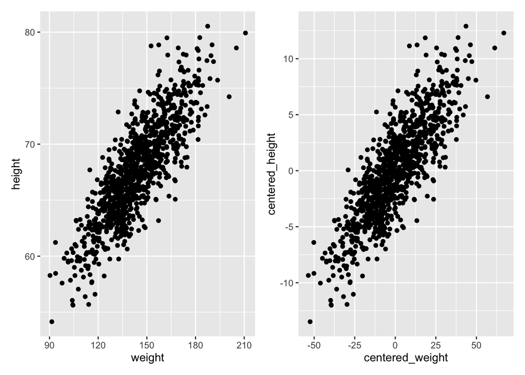

```r
d <- mutate(d, centered_height = height - mean(height))
d <- mutate(d, centered_weight = weight - mean(weight))

p1 <- ggplot(data = d, aes(x = weight, y = height)) + geom_point()
p2 <- ggplot(data = d, aes(x = centered_weight,
  y = centered_height)) + geom_point()

p1 + p2
```

```r
slope.test <- function(beta1, data){
  g <- ggplot(data=data, aes(x = centered_weight, y = centered_height))
  g <- g + geom_point()
  g <- g + geom_abline(intercept = 0, slope = beta1, size = 1, colour="blue", alpha=1/2)
  ols <- sum((data$centered_height - beta1 * data$centered_weight) ^2)
  g <- g + ggtitle(paste("Slope = ", beta1,
    "\nSum of Squared Deviations = ", round(ols, 3)))
  g
}

#manipulate(slope.test(beta1, data=d),
#  beta1 = slider(-1, 1, initial = 0, step = 0.005))
```

```r
b1 <- cor(d$height, d$weight) * sd(d$height)/sd(d$weight)
b1
```

```
## [1] 0.1950187
```

```r
b0 <- mean(d$height) - b1*mean(d$weight)
b0
```

```
## [1] 39.56545
```

```r
model <- lm(formula = height~ weight, data = d)
model
```

```
##
## Call:
## lm(formula = height ~ weight, data = d)
##
## Coefficients:
## (Intercept)       weight
##      39.565        0.195
```

```r
summary(model)
```

```
##
## Call:
## lm(formula = height ~ weight, data = d)
##
## Residuals:
##     Min      1Q  Median      3Q     Max
## -7.1519 -1.5206 -0.0535  1.5167  9.4439
##
## Coefficients:
##              Estimate Std. Error t value Pr(>|t|)
## (Intercept) 39.565446   0.595815   66.41   <2e-16 ***
## weight       0.195019   0.004107   47.49   <2e-16 ***
## ---
## Signif. codes:  0 '***' 0.001 '**' 0.01 '*' 0.05 '.' 0.1 ' ' 1
##
## Residual standard error: 2.389 on 998 degrees of freedom
## Multiple R-squared:  0.6932, Adjusted R-squared:  0.6929
## F-statistic:  2255 on 1 and 998 DF,  p-value: < 2.2e-16
```

```r
f <- "https://raw.githubusercontent.com/difiore/ada-2022-datasets/main/Street_et_al_2017.csv"
d <- read_csv(f, col_names = TRUE)
library(skimr)
skim(d)
```

Data summary

| Name | d |
| --- | --- |
| Number of rows | 301 |
| Number of columns | 13 |
| _______________________ |  |
| Column type frequency: |  |
| character | 2 |
| numeric | 11 |
| ________________________ |  |
| Group variables | None |

**Variable type: character**

| skim_variable | n_missing | complete_rate | min | max | empty | n_unique | whitespace |
| --- | --- | --- | --- | --- | --- | --- | --- |
| Species | 0 | 1 | 10 | 41 | 0 | 301 | 0 |
| Taxonomic_group | 0 | 1 | 10 | 15 | 0 | 4 | 0 |

**Variable type: numeric**

| skim_variable | n_missing | complete_rate | mean | sd | p0 | p25 | p50 | p75 | p100 | hist |
| --- | --- | --- | --- | --- | --- | --- | --- | --- | --- | --- |
| Social_learning | 98 | 0.67 | 2.30 | 16.51 | 0.00 | 0.00 | 0.00 | 0.00 | 214.00 | ▇▁▁▁▁ |
| Research_effort | 115 | 0.62 | 38.76 | 80.59 | 1.00 | 6.00 | 16.00 | 37.75 | 755.00 | ▇▁▁▁▁ |
| ECV | 117 | 0.61 | 68.49 | 82.84 | 1.63 | 11.82 | 58.55 | 86.20 | 491.27 | ▇▁▁▁▁ |
| Group_size | 114 | 0.62 | 13.26 | 15.20 | 1.00 | 3.12 | 7.50 | 18.23 | 91.20 | ▇▂▁▁▁ |
| Gestation | 161 | 0.47 | 164.50 | 38.00 | 59.99 | 138.35 | 166.03 | 183.26 | 274.78 | ▁▅▇▃▁ |
| Weaning | 185 | 0.39 | 311.09 | 253.08 | 40.00 | 121.66 | 234.16 | 388.78 | 1260.81 | ▇▃▁▁▁ |
| Longevity | 181 | 0.40 | 331.97 | 165.67 | 103.00 | 216.00 | 301.20 | 393.30 | 1470.00 | ▇▂▁▁▁ |
| Sex_maturity | 194 | 0.36 | 1480.23 | 999.23 | 283.18 | 701.52 | 1427.17 | 1894.11 | 5582.93 | ▇▆▂▁▁ |
| Body_mass | 63 | 0.79 | 6795.18 | 14229.83 | 31.23 | 739.44 | 3553.50 | 7465.00 | 130000.00 | ▇▁▁▁▁ |
| Maternal_investment | 197 | 0.35 | 478.64 | 292.07 | 99.99 | 255.88 | 401.35 | 592.22 | 1492.30 | ▇▅▂▁▁ |
| Repro_lifespan | 206 | 0.32 | 9064.97 | 4601.57 | 2512.16 | 6126.22 | 8325.89 | 10716.60 | 39129.57 | ▇▃▁▁▁ |

Brain size~social group size

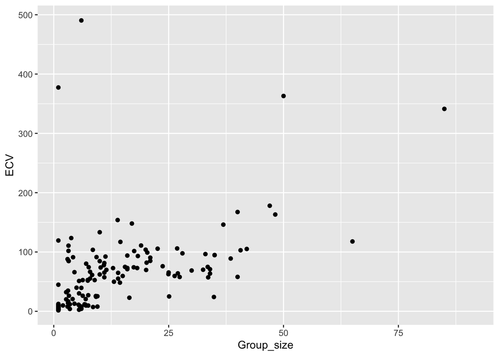

```r
d <- mutate(d, centered_ECV = ECV - mean(ECV))
d <- mutate(d, centered_Group_size = Group_size - mean(Group_size))

p1 <- ggplot(data = d, aes(x = Group_size, y = ECV)) + geom_point()


p1
```

Brain size~longevity

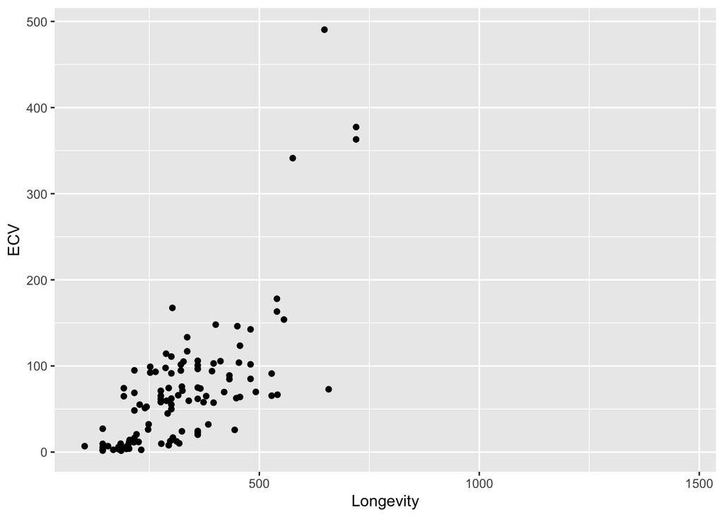

```r
d <- mutate(d, centered_ECV = ECV - mean(ECV))
d <- mutate(d, centered_Longevity = Longevity - mean(Longevity))

p1 <- ggplot(data = d, aes(x = Longevity, y = ECV)) + geom_point()


p1
```

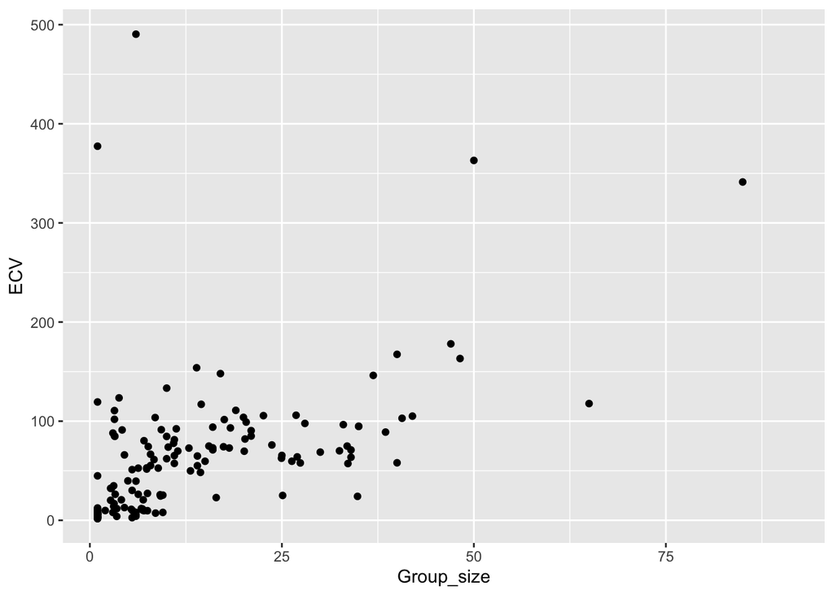

```r
d <- mutate(d, centered_ECV = ECV - mean(ECV))
d <- mutate(d, centered_Group_size = Group_size - mean(Group_size))

p1 <- ggplot(data = d, aes(x = Group_size, y = ECV)) + geom_point()


p1
```

Brain size~reproductive life span

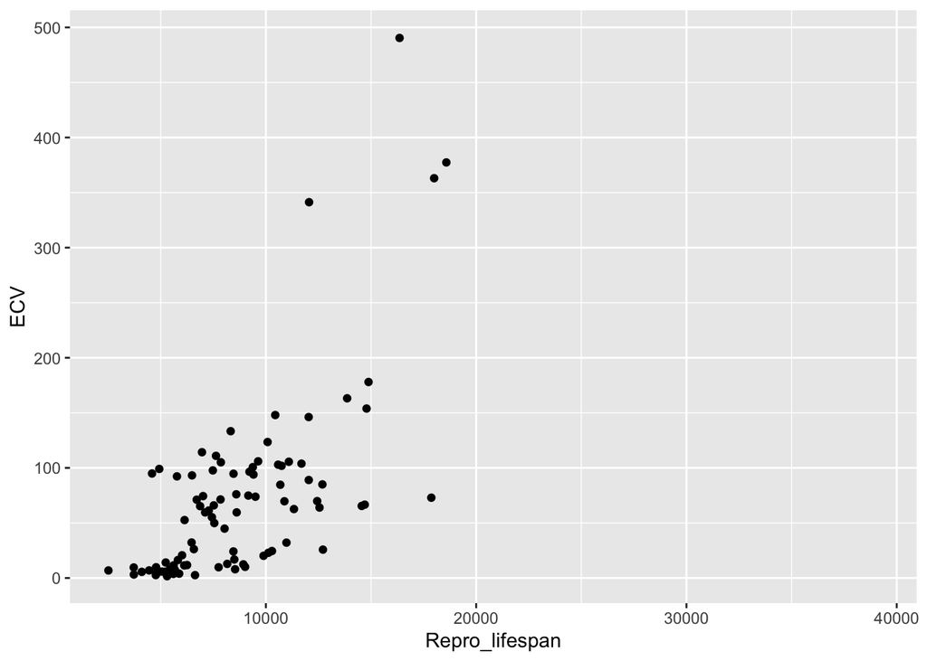

```r
d <- mutate(d, centered_ECV = ECV - mean(ECV))
d <- mutate(d, centered_Repro_lifespan = Repro_lifespan - mean(Repro_lifespan))

p1 <- ggplot(data = d, aes(x = Repro_lifespan, y = ECV)) + geom_point()


p1
```

Calculate ordinary least squares regression coefficients B1 and B0 for ECV ~ social group size

Removing NAs

```r
d_mod <- d %>% filter(!is.na(ECV) & !is.na(Group_size))
```

```r
b1.nonas <- cor(d_mod$ECV, d_mod$Group_size) * sd(d_mod$ECV)/sd(d_mod$Group_size)
b1.nonas
```

```
## [1] 2.463071
```

```r
b0.nonas <- mean(d_mod$ECV) - b1.nonas*mean(d_mod$Group_size)
b0.nonas
```

```
## [1] 30.35652
```

Calculating regression coefficients using ‘lm’ function

```r
model <- lm(formula = ECV~ Group_size, data = d_mod)
model
```

```
##
## Call:
## lm(formula = ECV ~ Group_size, data = d_mod)
##
## Coefficients:
## (Intercept)   Group_size
##      30.357        2.463
```

```r
summary(model)
```

```
##
## Call:
## lm(formula = ECV ~ Group_size, data = d_mod)
##
## Residuals:
##    Min     1Q Median     3Q    Max
## -92.05 -29.25 -15.14  13.07 445.28
##
## Coefficients:
##             Estimate Std. Error t value Pr(>|t|)
## (Intercept)  30.3565     6.7963   4.467 1.56e-05 ***
## Group_size    2.4631     0.3508   7.021 7.26e-11 ***
## ---
## Signif. codes:  0 '***' 0.001 '**' 0.01 '*' 0.05 '.' 0.1 ' ' 1
##
## Residual standard error: 60.31 on 149 degrees of freedom
## Multiple R-squared:  0.2486, Adjusted R-squared:  0.2436
## F-statistic:  49.3 on 1 and 149 DF,  p-value: 7.259e-11
```

For catarrhines:

Calculate ordinary least squares regression coefficients B1 and B0 for ECV ~ social group size

Removing NAs

```r
d_mod_cat <- d %>% filter(!is.na(ECV) & !is.na(Group_size) & Taxonomic_group=="Catarrhini")
```

```r
b1 <- cor(d_mod_cat$ECV, d_mod_cat$Group_size) * sd(d_mod_cat$ECV)/sd(d_mod_cat$Group_size)
b1
```

```
## [1] 1.265551
```

```r
b0 <- mean(d_mod_cat$ECV) - b1*mean(d_mod_cat$Group_size)
b0
```

```
## [1] 81.64085
```

Calculating regression coefficients using ‘lm’ function

```r
model <- lm(formula = ECV~ Group_size, data = d_mod_cat)
model
```

```
##
## Call:
## lm(formula = ECV ~ Group_size, data = d_mod_cat)
##
## Coefficients:
## (Intercept)   Group_size
##      81.641        1.266
```

```r
summary(model)
```

```
##
## Call:
## lm(formula = ECV ~ Group_size, data = d_mod_cat)
##
## Residuals:
##    Min     1Q Median     3Q    Max
## -74.24 -32.18 -17.76   4.20 401.18
##
## Coefficients:
##             Estimate Std. Error t value Pr(>|t|)
## (Intercept)  81.6408    15.3317   5.325 1.27e-06 ***
## Group_size    1.2656     0.6192   2.044   0.0449 *
## ---
## Signif. codes:  0 '***' 0.001 '**' 0.01 '*' 0.05 '.' 0.1 ' ' 1
##
## Residual standard error: 76.4 on 67 degrees of freedom
## Multiple R-squared:  0.05869,    Adjusted R-squared:  0.04464
## F-statistic: 4.177 on 1 and 67 DF,  p-value: 0.0449
```

For platyrrhines:

Calculate ordinary least squares regression coefficients B1 and B0 for ECV ~ social group size

Removing NAs

```r
d_mod_plat <- d %>% filter(!is.na(ECV) & !is.na(Group_size) & Taxonomic_group=="Platyrrhini")
```

```r
b1 <- cor(d_mod_plat$ECV, d_mod_plat$Group_size) * sd(d_mod_plat$ECV)/sd(d_mod_plat$Group_size)
b1
```

```
## [1] 1.965176
```

```r
b0 <- mean(d_mod_plat$ECV) - b1*mean(d_mod_plat$Group_size)
b0
```

```
## [1] 16.18121
```

Calculating regression coefficients using ‘lm’ function

```r
model <- lm(formula = ECV~ Group_size, data = d_mod_plat)
model
```

```
##
## Call:
## lm(formula = ECV ~ Group_size, data = d_mod_plat)
##
## Coefficients:
## (Intercept)   Group_size
##      16.181        1.965
```

```r
summary(model)
```

```
##
## Call:
## lm(formula = ECV ~ Group_size, data = d_mod_plat)
##
## Residuals:
##     Min      1Q  Median      3Q     Max
## -60.528 -19.817  -3.568  19.968  72.344
##
## Coefficients:
##             Estimate Std. Error t value Pr(>|t|)
## (Intercept)  16.1812     7.3865   2.191 0.035646 *
## Group_size    1.9652     0.4554   4.315 0.000136 ***
## ---
## Signif. codes:  0 '***' 0.001 '**' 0.01 '*' 0.05 '.' 0.1 ' ' 1
##
## Residual standard error: 26.98 on 33 degrees of freedom
## Multiple R-squared:  0.3607, Adjusted R-squared:  0.3414
## F-statistic: 18.62 on 1 and 33 DF,  p-value: 0.0001364
```

For strepsirhines:

Calculate ordinary least squares regression coefficients B1 and B0 for ECV ~ social group size

Removing NAs

```r
d_mod_strep <- d %>% filter(!is.na(ECV) & !is.na(Group_size) & Taxonomic_group=="Strepsirhini")
```

```r
b1 <- cor(d_mod_strep$ECV, d_mod_strep$Group_size) * sd(d_mod_strep$ECV)/sd(d_mod_strep$Group_size)
b1
```

```
## [1] 1.840664
```

```r
b0 <- mean(d_mod_strep$ECV) - b1*mean(d_mod_strep$Group_size)
b0
```

```
## [1] 8.176384
```

Calculating regression coefficients using ‘lm’ function

```r
model <- lm(formula = ECV~ Group_size, data = d_mod_strep)
model
```

```
##
## Call:
## lm(formula = ECV ~ Group_size, data = d_mod_strep)
##
## Coefficients:
## (Intercept)   Group_size
##       8.176        1.841
```

```r
summary(model)
```

```
##
## Call:
## lm(formula = ECV ~ Group_size, data = d_mod_strep)
##
## Residuals:
##     Min      1Q  Median      3Q     Max
## -15.650  -6.167  -2.777   1.300  34.833
##
## Coefficients:
##             Estimate Std. Error t value Pr(>|t|)
## (Intercept)   8.1764     2.1354   3.829 0.000404 ***
## Group_size    1.8407     0.4728   3.893 0.000332 ***
## ---
## Signif. codes:  0 '***' 0.001 '**' 0.01 '*' 0.05 '.' 0.1 ' ' 1
##
## Residual standard error: 10.37 on 44 degrees of freedom
## Multiple R-squared:  0.2562, Adjusted R-squared:  0.2393
## F-statistic: 15.15 on 1 and 44 DF,  p-value: 0.0003324
```

Now back to the whole dataset, not filtering by groups:

Calculate standard error for the slope coefficient, the 95% CI, and p-value associated with this coefficient by hand

```r
m <- lm(data = d_mod, ECV ~ Group_size)
summary(m)
```

```
##
## Call:
## lm(formula = ECV ~ Group_size, data = d_mod)
##
## Residuals:
##    Min     1Q Median     3Q    Max
## -92.05 -29.25 -15.14  13.07 445.28
##
## Coefficients:
##             Estimate Std. Error t value Pr(>|t|)
## (Intercept)  30.3565     6.7963   4.467 1.56e-05 ***
## Group_size    2.4631     0.3508   7.021 7.26e-11 ***
## ---
## Signif. codes:  0 '***' 0.001 '**' 0.01 '*' 0.05 '.' 0.1 ' ' 1
##
## Residual standard error: 60.31 on 149 degrees of freedom
## Multiple R-squared:  0.2486, Adjusted R-squared:  0.2436
## F-statistic:  49.3 on 1 and 149 DF,  p-value: 7.259e-11
```

CI using confint function

```r
CI <- confint(m, level = 1-0.05)
CI
```

```
##                 2.5 %    97.5 %
## (Intercept) 16.926896 43.786153
## Group_size   1.769874  3.156269
```

Getting m.summary

```r
m.summary <- tidy(m)
m.summary
```

```
## # A tibble: 2 × 5
##   term        estimate std.error statistic  p.value
##   <chr>          <dbl>     <dbl>     <dbl>    <dbl>
## 1 (Intercept)    30.4      6.80       4.47 1.56e- 5
## 2 Group_size      2.46     0.351      7.02 7.26e-11
```

Calculate standard error by hand

```r
n <- nrow(d_mod)
mean_x <- mean(d_mod$Group_size)
y_pred <- b0.nonas + b1.nonas*d_mod$Group_size
y_error = d_mod$ECV - y_pred

num <- sum(y_error^2)
den <- (n-2)* sum((d_mod$Group_size - mean_x)^2)

se <- sqrt(num/den)
se
```

```
## [1] 0.3508061
```

Calculate 95% CI by hand

```r
# by hand
alpha <- 0.05
lower <- m.summary$estimate -
  qt(1 - alpha / 2, df = nrow(d_mod) - 2) * m.summary$std.error
upper <- m.summary$estimate +
  qt(1 - alpha / 2, df = nrow(d_mod) - 2) * m.summary$std.error
CI <- cbind(lower, upper)
rownames(CI) <- c("(Intercept)", "Group_size")
colnames(CI) <- c(paste0(as.character(alpha/2 * 100), " %"),paste0(as.character((1-alpha/2) * 100), " %"))
CI
```

```
##                 2.5 %    97.5 %
## (Intercept) 16.926896 43.786153
## Group_size   1.769874  3.156269
```

Calculate p-value by hand

```r
m.summary$calc.statistic <- (m.summary$estimate-0)/m.summary$std.error
m.summary$calc.p.value <- 2 * pt(m.summary$calc.statistic,
  df=nrow(d)-2, lower.tail = FALSE)
m.summary
```

```
## # A tibble: 2 × 7
##   term        estimate std.error statistic  p.value calc.statistic calc.p.value
##   <chr>          <dbl>     <dbl>     <dbl>    <dbl>          <dbl>        <dbl>
## 1 (Intercept)    30.4      6.80       4.47 1.56e- 5           4.47     1.13e- 5
## 2 Group_size      2.46     0.351      7.02 7.26e-11           7.02     1.48e-11
```

Use a permutation approach with 1000 permutations to generate a null sampling distribution for slope coefficient. What is it that you need to permute? What is the p-value associated with your original slope coefficient?

```r
permuted.slope <- d_mod %>%
  # specify model
  specify(ECV ~ Group_size) %>%
  # use a null hypothesis of independence
  hypothesize(null = "independence") %>%
  # generate permutation replicates
  generate(reps = 1000, type = "permute") %>%
  # calculate the slope statistic
  calculate(stat = "slope")

head(permuted.slope)
```

```
## Response: ECV (numeric)
## Explanatory: Group_size (numeric)
## Null Hypothesis: independence
## # A tibble: 6 × 2
##   replicate    stat
##       <int>   <dbl>
## 1         1  0.801
## 2         2 -0.102
## 3         3  0.0993
## 4         4  0.0852
## 5         5 -0.314
## 6         6  0.0786
```

To generate the null sampling distribution, you need to permute values of the response variable (e.g. ECV) under null hypothesis that the response variable is independent of the explanatory variable (e.g. group size).

Calculate original slope, then obtain associated p-value

```r
#Original Slope Calculation
# first define alpha, CI boundaries, and critical values
alpha <- 0.05
confidence_level <- 1 - alpha
p_lower <- alpha / 2
p_upper <- 1 - (alpha / 2)
degrees_of_freedom <- nrow(d) - 2
critical_value <- qt(p_upper, df = degrees_of_freedom)

# original slope
original.slope <- lm(data = d_mod, ECV ~ Group_size) %>%
  # tidy the model and add the CI based on the t distribution
  tidy(conf.int=TRUE, conf.level=confidence_level) %>%
  # or manually calculate the CI based on the t distribution
  mutate(
    lower = estimate - std.error * critical_value,
    upper = estimate + std.error * critical_value
  ) %>%
  filter(term=="Group_size")
original.slope # show model results for slope of Group_size
```

```
## # A tibble: 1 × 9
##   term      estimate std.error statistic  p.value conf.low conf.high lower upper
##   <chr>        <dbl>     <dbl>     <dbl>    <dbl>    <dbl>     <dbl> <dbl> <dbl>
## 1 Group_si…     2.46     0.351      7.02 7.26e-11     1.77      3.16  1.77  3.15
```

```r
#p-value calculation
p.value <- permuted.slope %>%
  # add a column of the absolute value of the slope
  mutate(abs_stat=abs(stat)) %>%
  # calculate a summary statistic
  summarize(
    # calculate proportion of cases where the absolute value
    # of the permuted slope is greater than or equal to the
    # absolute value of the observed slope
    estimate = mean(abs_stat >= abs(pull(original.slope, estimate)))
  )

p.value
```

```
## # A tibble: 1 × 1
##   estimate
##      <dbl>
## 1        0
```

Use bootstrapping to generate 95% CI for your estimate of slope coefficient using both percentile method and theory-based method.

Generating bootstraps

```r
boot.slope <- d_mod %>%
  # specify model
  specify(ECV ~ Group_size) %>%
  # generate bootstrap replicates
  generate(reps = 1000, type = "bootstrap") %>%
  # calculate the slope statistic
  calculate(stat = "slope")

head(boot.slope)
```

```
## Response: ECV (numeric)
## Explanatory: Group_size (numeric)
## # A tibble: 6 × 2
##   replicate  stat
##       <int> <dbl>
## 1         1  2.41
## 2         2  1.64
## 3         3  2.09
## 4         4  2.05
## 5         5  2.31
## 6         6  3.44
```

Creating CIs for regression coefficients using two methods

```r
boot.slope.summary <- boot.slope %>%
  # summarize the mean, t distribution based CI, and quantile-based CI
  summarize(
    # mean of stat
    estimate = mean(stat),
    # std error of stat
    std.error = sd(stat),
    # calculate the CI based on the SE and t distribution
    boot.se.method.low = estimate - std.error * critical_value,
    boot.se.method.high = estimate + std.error * critical_value,
    # calculate the CI based on the quantile (percentile)  method
    boot.percent.method.low = quantile(stat, p_lower),
    boot.percent.method.high = quantile(stat, p_upper)
  )
# show summary of bootstrap sampling distribution
boot.slope.summary
```

```
## # A tibble: 1 × 6
##   estimate std.error boot.se.method.low boot.se.method.high boot.percent.method…
##      <dbl>     <dbl>              <dbl>               <dbl>                <dbl>
## 1     2.42     0.467               1.50                3.34                 1.47
## # … with 1 more variable: boot.percent.method.high <dbl>
```